# Analysis_Final2

```python
import math
from random import *
import numpy as np
import matplotlib.pyplot as plt
import pandas as pd
import seaborn as sns
from IPython.display import Image
from IPython.core.display import HTML
```

## 1- Number of datasets succeeded by each tool in each time budget

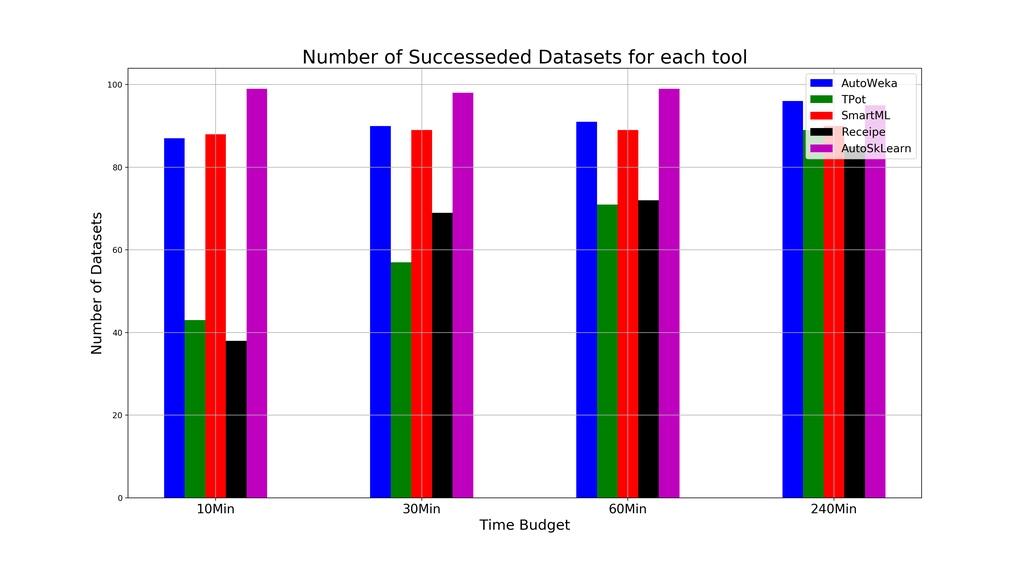

```python
Image("Success.png")
```

## 2- How many times each tool has been the best performance?

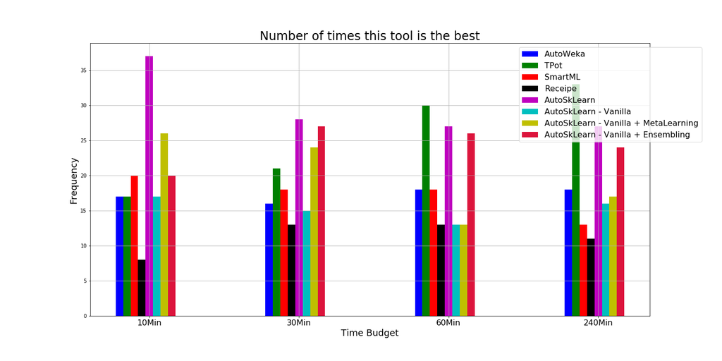

```python
Image('Best_All.png')
```

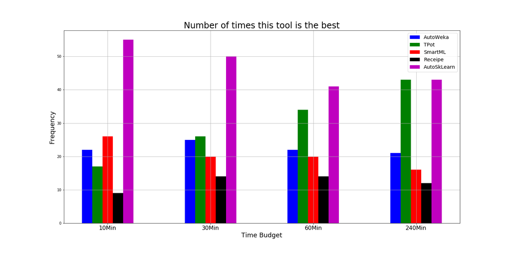

```python
Image('Best_Main.png')
```

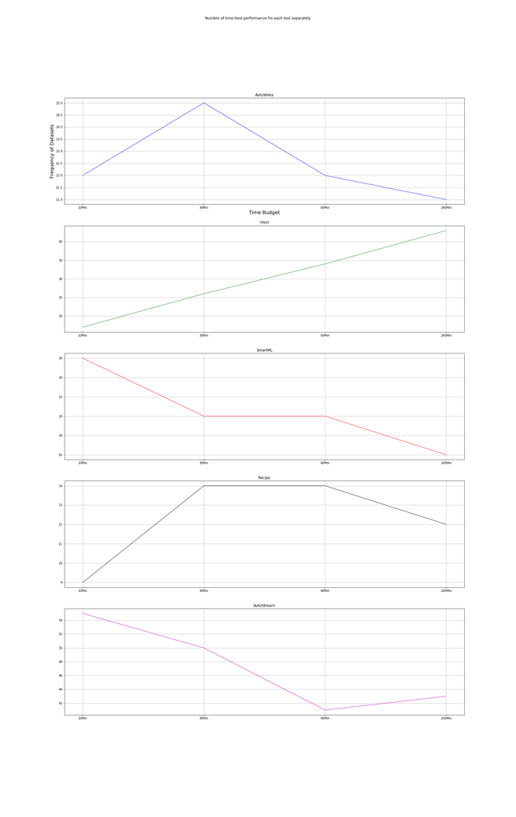

```python
Image('Diff_MetaLearning2.png')
```

## 3- What is the average ranking for each tool?

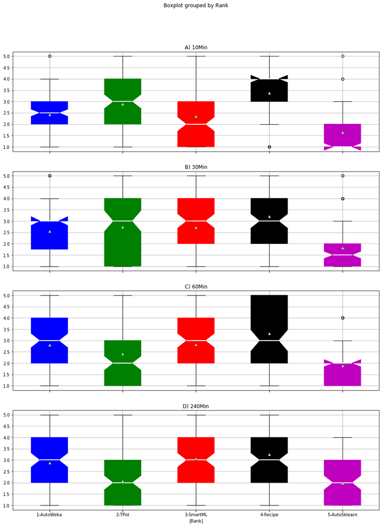

```python
Image('AvgRank_Main.png')
```

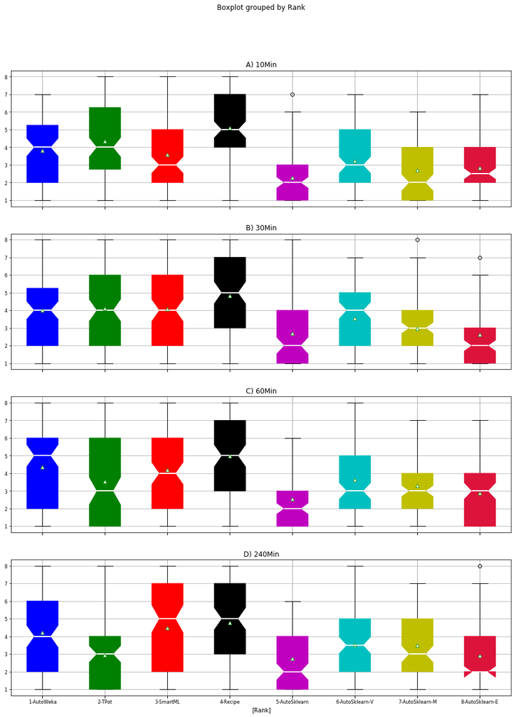

```python
Image('AvgRank_All.png')
```

## 5- How many times Meta-learning performed lower in scikit learn?

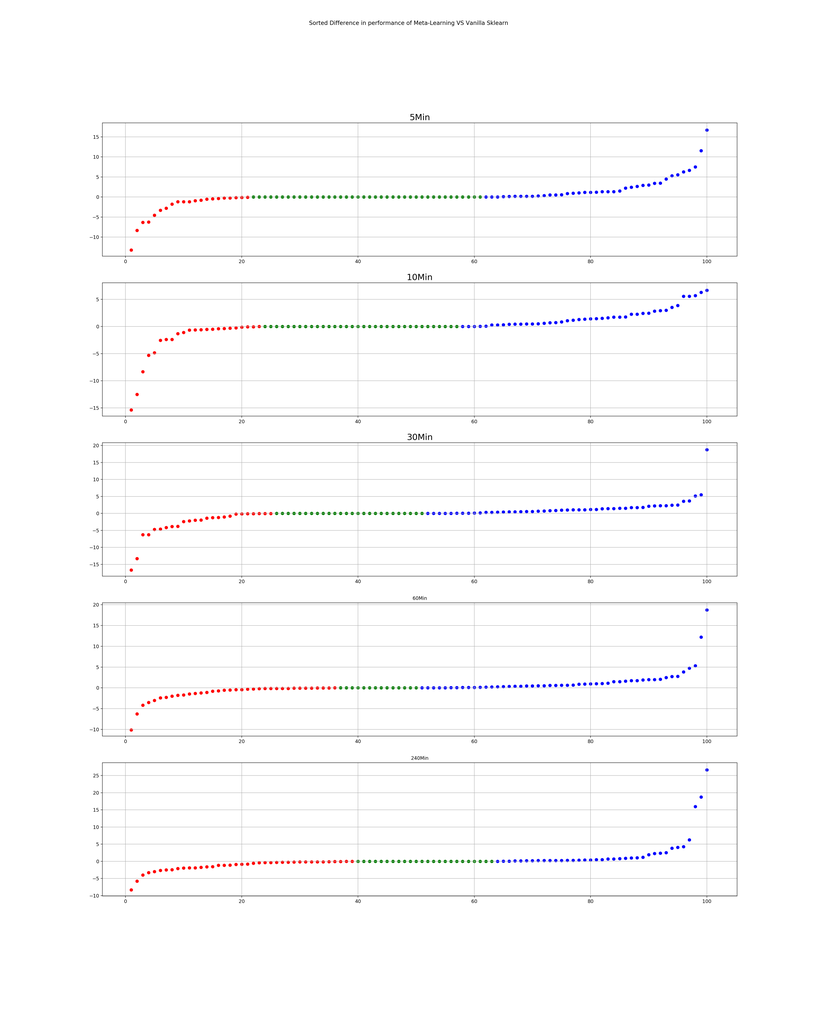

```python
Image('Diff_MetaLearning.png')
```

## 6- Same for ensembling

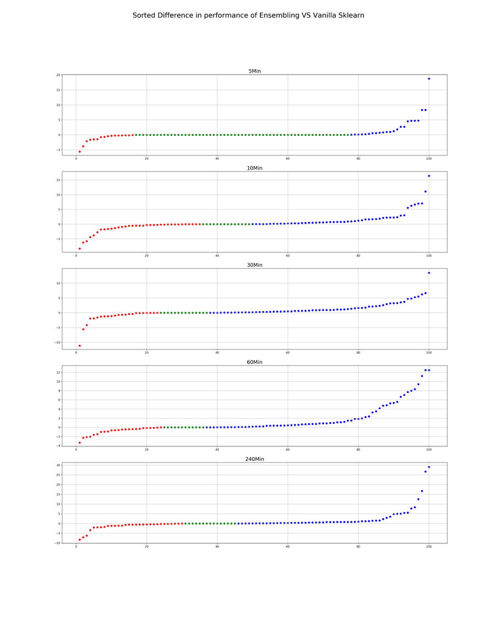

```python
Image('Diff_Ensembling.png')
```

## 7- Comparison between TPOT and recipe ONLY (Performance and Search Space)¶

### TPOT Search Space:

#### Classifiers (11)

#### Preprocessors & Extractors (14)

#### Feature Selectors (5)

### Recipe Search Space:

#### Classifiers (20)

#### Preprocessors & Extractors (15)

#### Feature Selection (8)

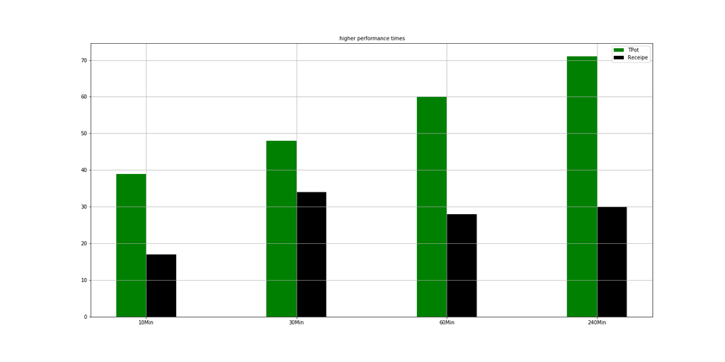

```python
Image('Best_Genetic.png')
```

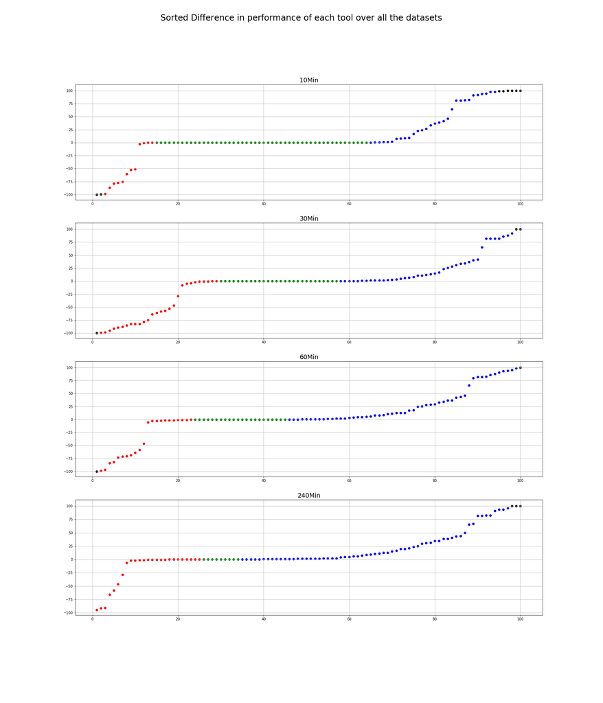

```python
Image('Diff_Genetic.png')
```

## 8- Does the impact of Meta-learning increase or decrease by more time?

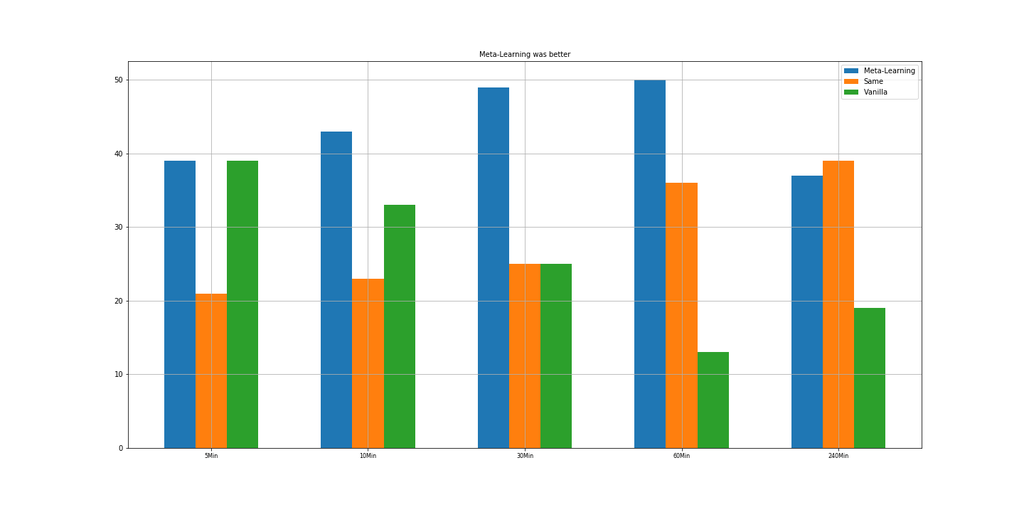

```python
Image('Meta_Best_Worse.png')
```

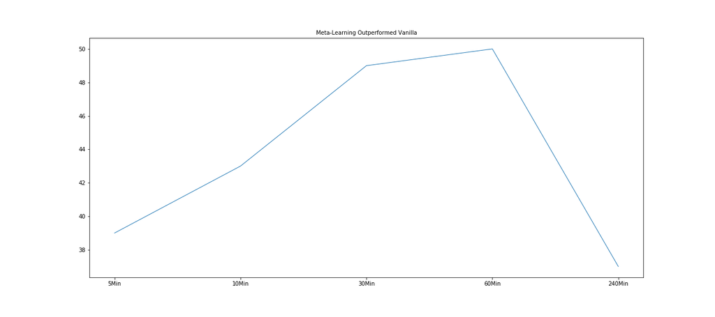

```python
Image('MetaImpact.png')
```

## 9. Performance Gain by increasing time budget

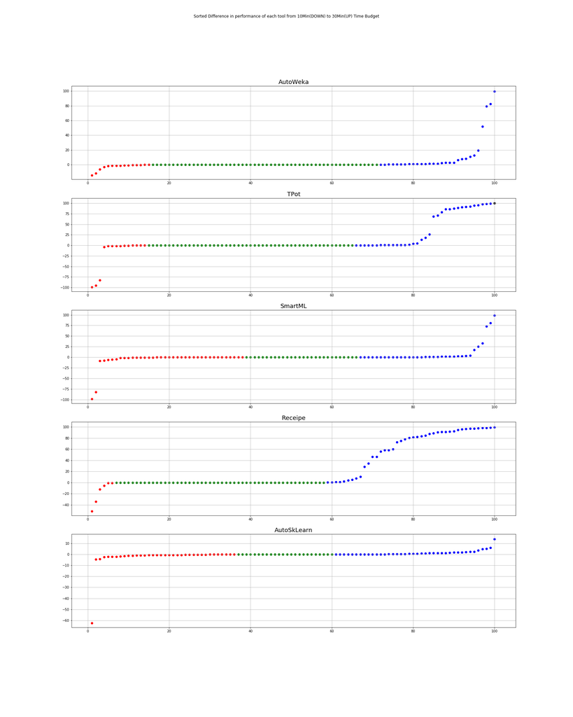

```python
Image('Diff_Main_10_30.png')
```

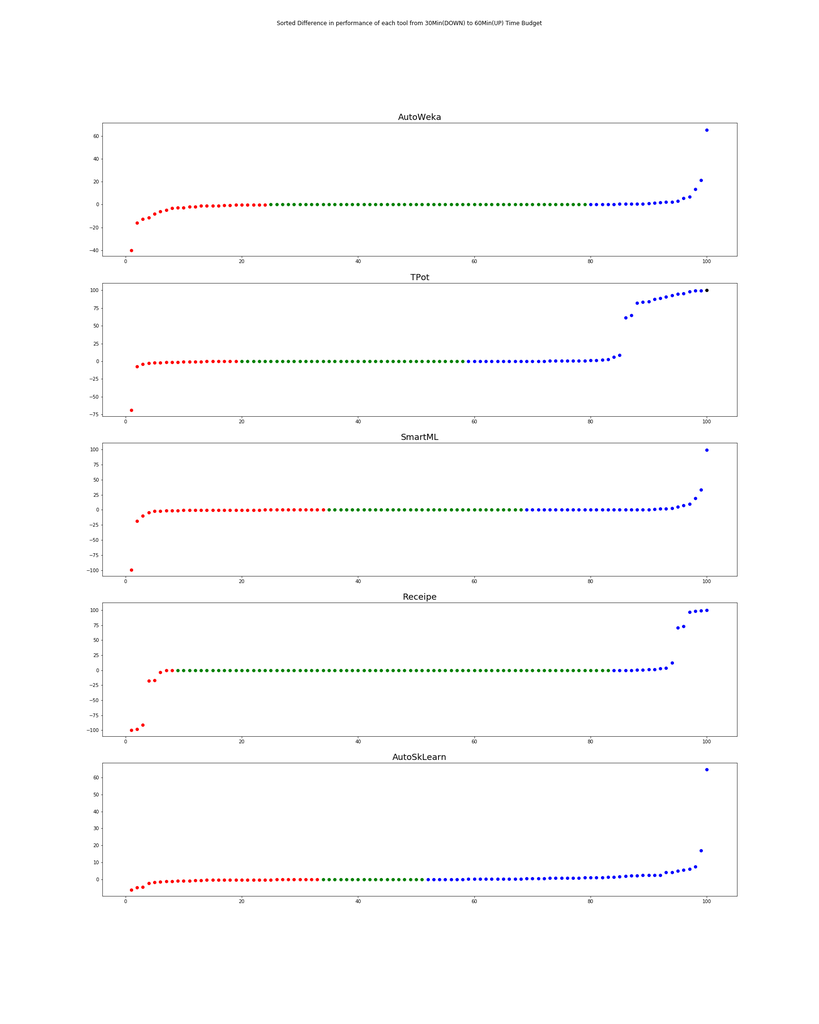

```python
Image('Diff_Main_30_60.png')
```

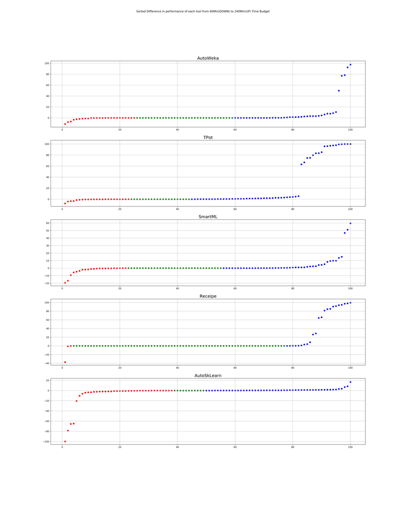

```python
Image('Diff_Main_60_240.png')
```

## 10. Output pipelines for datasets where TPOT outperform AutoSklearn

** CHURN DATASET **  
**TPOT:**  
Pipeline(memory=None,steps=[('extratreesclassifier')])

**AutoSklearn:**  
{'balancing:strategy': 'none',  
'categorical_encoding:**choice**': 'one_hot_encoding',  
'classifier:**choice**': 'random_forest',  
'imputation:strategy': 'mean',  
'preprocessor:**choice**': 'no_preprocessing',  
'rescaling:**choice**': 'standardize',  
'categorical_encoding:one_hot_encoding}

** Adult DATASET **  
**TPOT:**  
Pipeline(memory=None, steps=[('gradientboostingclassifier')])

**AutoSklearn:**  
{'balancing:strategy': 'none',  
'categorical_encoding:**choice**': 'one_hot_encoding',  
'classifier:**choice**': 'random_forest',  
'imputation:strategy': 'median',  
'preprocessor:**choice**': 'feature_agglomeration',  
'rescaling:**choice**': 'robust_scaler',  
'categorical_encoding:one_hot_encoding}

** Yeast DATASET **  
**TPOT:**  
Pipeline(memory=None, steps=[('randomforestclassifier')])

**AutoSklearn:**  
{'balancing:strategy': 'none',  
'categorical_encoding:**choice**': 'one_hot_encoding',  
'classifier:**choice**': 'extra_trees',  
'imputation:strategy': 'median',  
'preprocessor:**choice**': 'feature_agglomeration',  
'rescaling:**choice**': 'normalize',  
'categorical_encoding:one_hot_encoding }

** Eucalputus DATASET **  
**TPOT:**  
Pipeline(memory=None, steps=[('polynomialfeatures', 'gradientboostingclassifier')])

**AutoSklearn:**  
({'balancing:strategy': 'none',  
'categorical_encoding:**choice**': 'no_encoding',  
'classifier:**choice**': 'extra_trees',  
'imputation:strategy': 'most_frequent',  
'preprocessor:**choice**': 'polynomial',  
'rescaling:**choice**': 'normalize'

** Ecoli DATASET **  
**TPOT:**  
Pipeline(memory=None, steps=[('featureunion', transformer_list=[('rbfsampler', 'functiontransformer')])

**AutoSklearn:**  
{'balancing:strategy': 'weighting',  
'categorical_encoding:**choice**': 'no_encoding',  
'classifier:**choice**': 'libsvm_svc',  
'imputation:strategy': 'median',  
'preprocessor:**choice**': 'random_trees_embedding',  
'rescaling:**choice**': 'standardize'}

### AutoSklearn Search Space:

1. Adaboost
2. BernoulliNB
3. GaussianNB
4. DecisionTreeClassifier
5. ExtraTreesClassifier
6. RandomForestClassifier
7. GradientBoostingClassifier
8. KNeighborsClassifier
9. svm.LinearSVC and non linear
10. LogisticRegression
11. XGBClassifier
12. LDA
13. Multinomial Naive-Bayes
14. SGD
15. QDA
16. Passive Aggressive

#### Preprocessors & Extractors (16):

1. Densifier
2. FastICA
3. cluster.FeatureAgglomeration
4. ExtraTrees
5. KernelPCA
6. Normalizer
7. Nystroem Sampler
8. PCA
9. PolynomialFeatures
10. Select Percentile
11. OneHotEncoder
12. Kitchen Sink
13. Imputation
14. Balancing
15. Variance Threshold
16. Rescaling

#### Feature Selectors (1):

1. truncated SVD

## 11- How models are over-fitted for each tool over time budget?

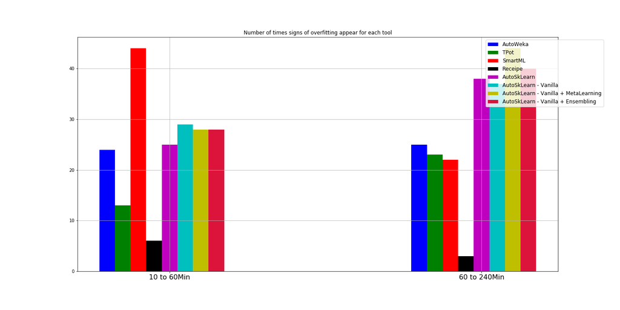

```python
Image('Overfit_All.png')
```

## 12- Try to correlate the above points with the datasets meta-features

Unfortunately, all correlations with meta-features are weak to moderate correlations according to spearman rank coefficient

## 13- Most frequent classifiers for each tool

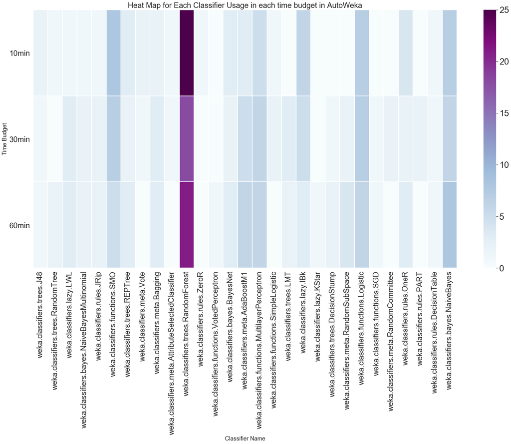

```python
#### Most frequesnt classifiers chosen by Weka
Image('weka_most.png')
```

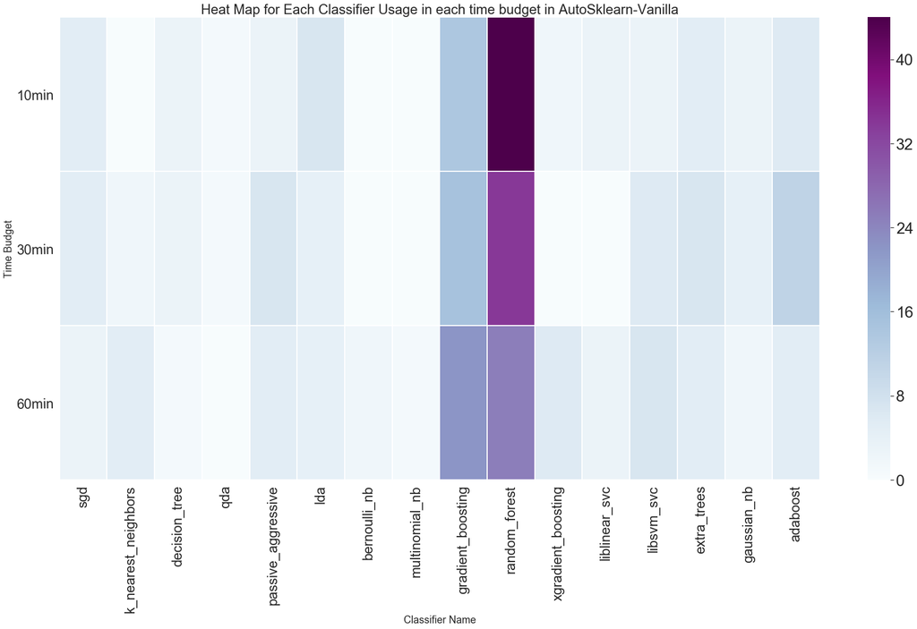

```python
#### Most frequesnt classifiers chosen by AutoSklearn
Image('sklearn_most.png')
```

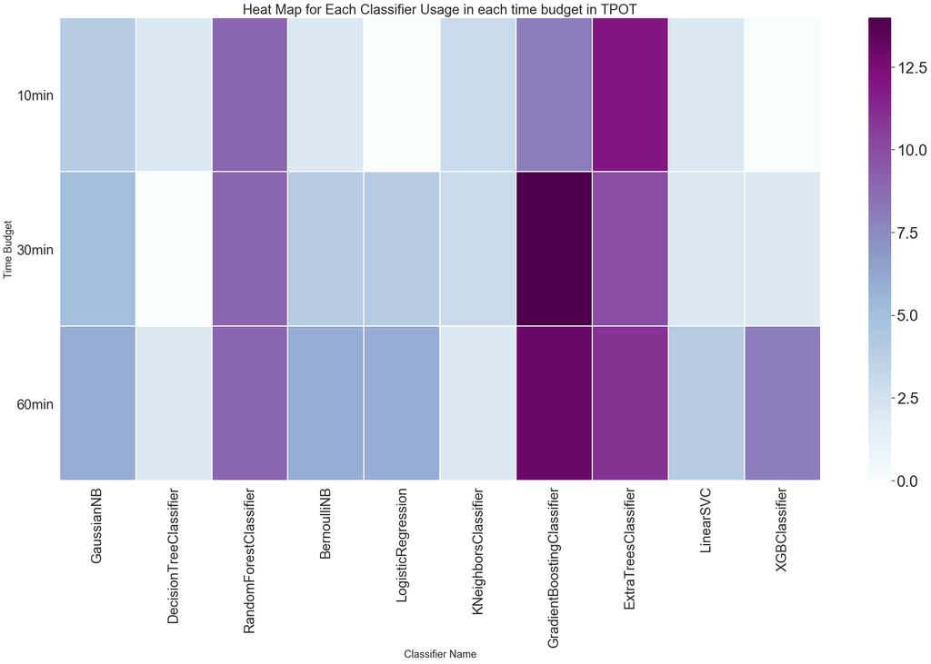

```python
#### Most frequesnt classifiers chosen by TPOT
Image('tpot.png')
```

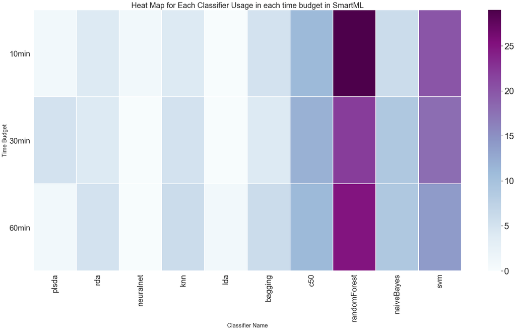

```python
#### Most frequesnt classifiers chosen by SmartML
Image('smartml.png')
```

## 14- FScore - Analysis

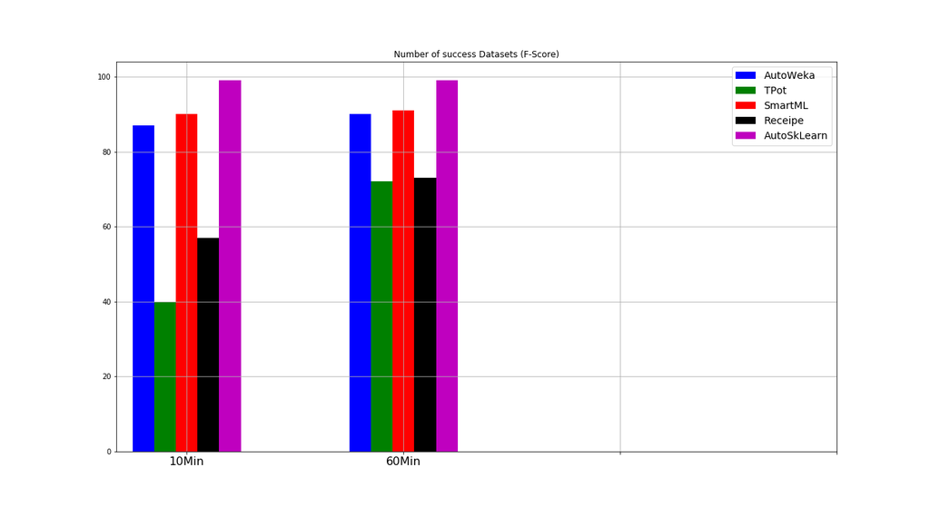

```python
# Number of Succeeded datasets for each tool
Image('SuccessF.png')
```

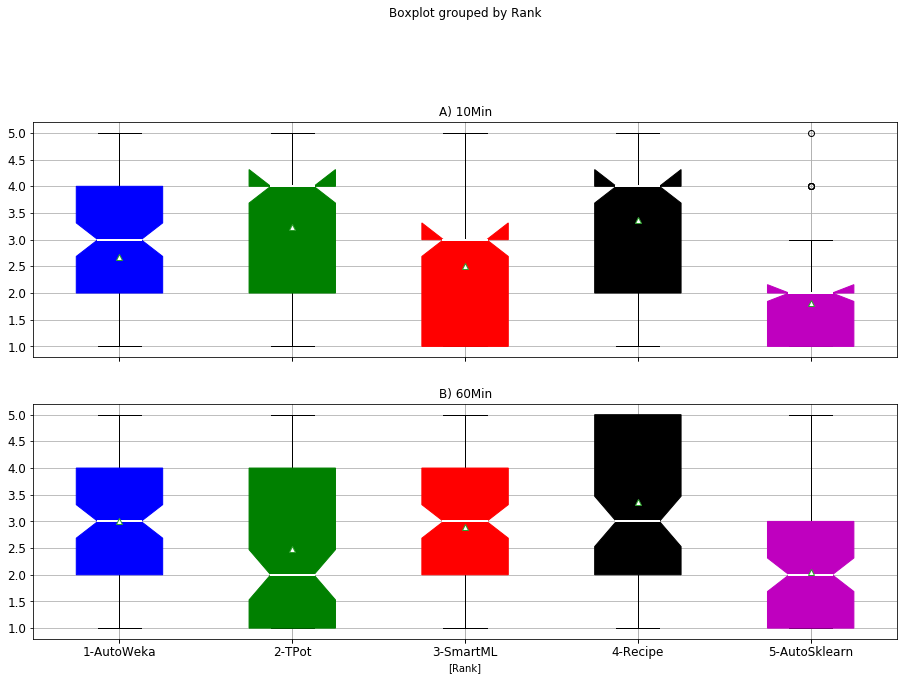

```python
Image('AvgRank_MainF.png')
```

### Performance Gain by increasing time budget

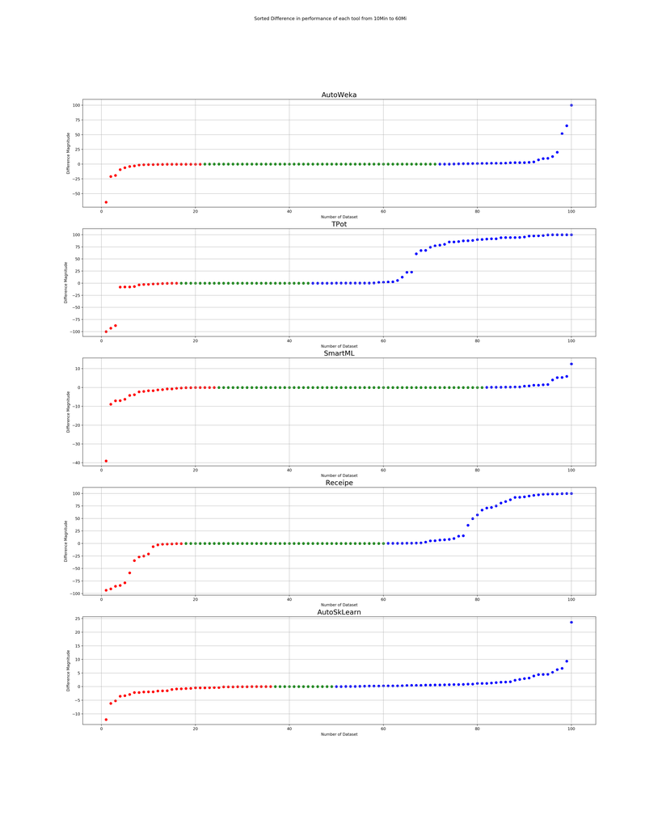

```python
Image('Diff_MainF_10_60.png')
```

#### Meta-Learning Vs Vanilla Version - FScore

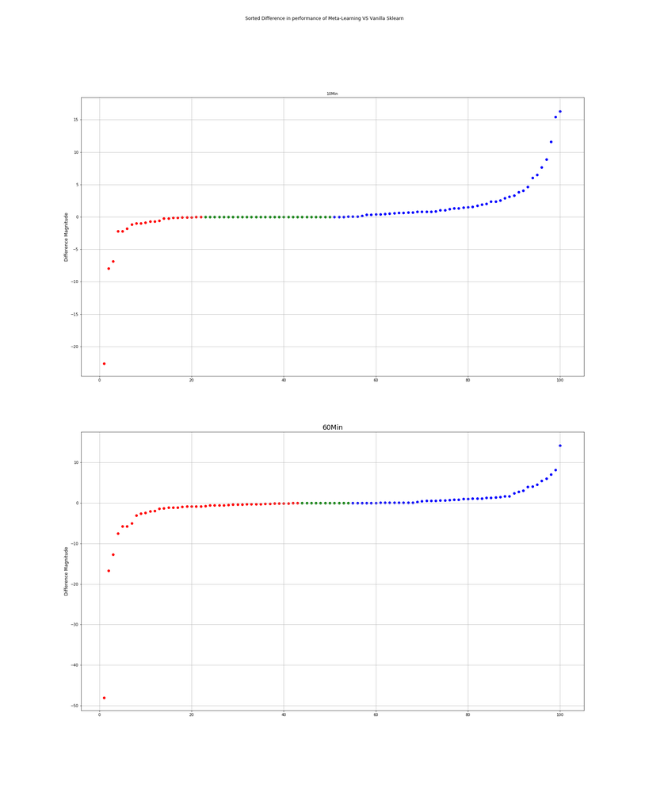

```python
Image('Diff_MetaLearningF.png')
```

#### Same for ensembling

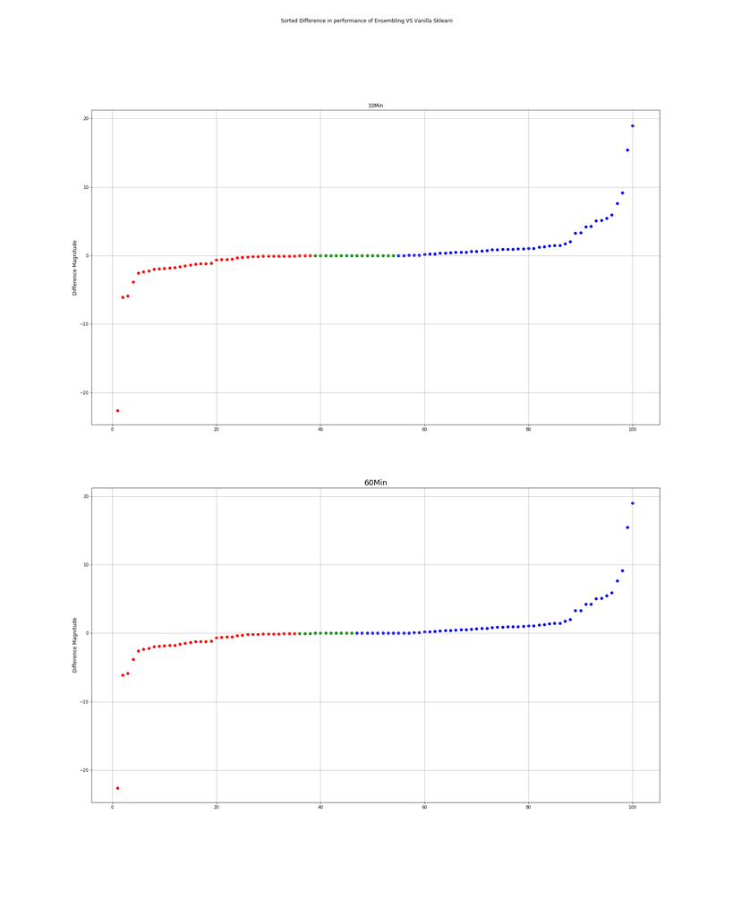

```python
Image('Diff_EnsemblingF.png')
```

#### How many times each tool has been the best performance?

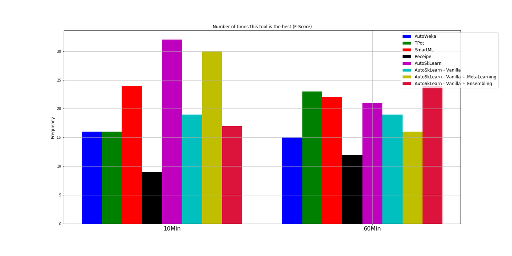

```python
Image('Best_AllF.png')
```